# SI 618: Data Manipulation and Analysis

## 05 - Applied Statistics I

### Dr. Chris Teplovs, School of Information, University of Michigan

This work is licensed under a [Creative Commons Attribution-NonCommercial-ShareAlike 4.0 International License](http://creativecommons.org/licenses/by-nc-sa/4.0/).

Version 2023.09.27.1.CT

## Correlation and Regression

### Wine quality

https://www.kaggle.com/uciml/red-wine-quality-cortez-et-al-2009/home

Warnings usually just cause us unnessary stress. The next code block silences warnings.

```python
import warnings
warnings.filterwarnings('ignore')
```

```python
import pandas as pd
import seaborn as sns
import numpy as np
import matplotlib.pyplot as plt
```

```python
wine = pd.read_csv('https://raw.githubusercontent.com/umsi-data-science/data/main/winequality-red.csv')
wine.head()
```

|  | fixed acidity | volatile acidity | citric acid | residual sugar | chlorides | free sulfur dioxide | total sulfur dioxide | density | pH | sulphates | alcohol | quality |
| --- | --- | --- | --- | --- | --- | --- | --- | --- | --- | --- | --- | --- |
| 0 | 7.4 | 0.70 | 0.00 | 1.9 | 0.076 | 11.0 | 34.0 | 0.9978 | 3.51 | 0.56 | 9.4 | 5 |
| 1 | 7.8 | 0.88 | 0.00 | 2.6 | 0.098 | 25.0 | 67.0 | 0.9968 | 3.20 | 0.68 | 9.8 | 5 |
| 2 | 7.8 | 0.76 | 0.04 | 2.3 | 0.092 | 15.0 | 54.0 | 0.9970 | 3.26 | 0.65 | 9.8 | 5 |
| 3 | 11.2 | 0.28 | 0.56 | 1.9 | 0.075 | 17.0 | 60.0 | 0.9980 | 3.16 | 0.58 | 9.8 | 6 |
| 4 | 7.4 | 0.70 | 0.00 | 1.9 | 0.076 | 11.0 | 34.0 | 0.9978 | 3.51 | 0.56 | 9.4 | 5 |

### Q1: List the 5 largest correlations in the wine quality dataset

Feeling ambitious? Try to get the following output:

|  | var1 | var2 | corr |
| --- | --- | --- | --- |
| 12 | fixed acidity | pH | -0.682978 |
| 14 | citric acid | fixed acidity | 0.671703 |
| 16 | density | fixed acidity | 0.668047 |
| 18 | free sulfur dioxide | total sulfur dioxide | 0.667666 |
| 20 | citric acid | volatile acidity | -0.552496 |

```python
wine.corr()
```

|  | fixed acidity | volatile acidity | citric acid | residual sugar | chlorides | free sulfur dioxide | total sulfur dioxide | density | pH | sulphates | alcohol | quality |
| --- | --- | --- | --- | --- | --- | --- | --- | --- | --- | --- | --- | --- |
| fixed acidity | 1.000000 | -0.256131 | 0.671703 | 0.114777 | 0.093705 | -0.153794 | -0.113181 | 0.668047 | -0.682978 | 0.183006 | -0.061668 | 0.124052 |
| volatile acidity | -0.256131 | 1.000000 | -0.552496 | 0.001918 | 0.061298 | -0.010504 | 0.076470 | 0.022026 | 0.234937 | -0.260987 | -0.202288 | -0.390558 |
| citric acid | 0.671703 | -0.552496 | 1.000000 | 0.143577 | 0.203823 | -0.060978 | 0.035533 | 0.364947 | -0.541904 | 0.312770 | 0.109903 | 0.226373 |
| residual sugar | 0.114777 | 0.001918 | 0.143577 | 1.000000 | 0.055610 | 0.187049 | 0.203028 | 0.355283 | -0.085652 | 0.005527 | 0.042075 | 0.013732 |
| chlorides | 0.093705 | 0.061298 | 0.203823 | 0.055610 | 1.000000 | 0.005562 | 0.047400 | 0.200632 | -0.265026 | 0.371260 | -0.221141 | -0.128907 |
| free sulfur dioxide | -0.153794 | -0.010504 | -0.060978 | 0.187049 | 0.005562 | 1.000000 | 0.667666 | -0.021946 | 0.070377 | 0.051658 | -0.069408 | -0.050656 |
| total sulfur dioxide | -0.113181 | 0.076470 | 0.035533 | 0.203028 | 0.047400 | 0.667666 | 1.000000 | 0.071269 | -0.066495 | 0.042947 | -0.205654 | -0.185100 |
| density | 0.668047 | 0.022026 | 0.364947 | 0.355283 | 0.200632 | -0.021946 | 0.071269 | 1.000000 | -0.341699 | 0.148506 | -0.496180 | -0.174919 |
| pH | -0.682978 | 0.234937 | -0.541904 | -0.085652 | -0.265026 | 0.070377 | -0.066495 | -0.341699 | 1.000000 | -0.196648 | 0.205633 | -0.057731 |
| sulphates | 0.183006 | -0.260987 | 0.312770 | 0.005527 | 0.371260 | 0.051658 | 0.042947 | 0.148506 | -0.196648 | 1.000000 | 0.093595 | 0.251397 |
| alcohol | -0.061668 | -0.202288 | 0.109903 | 0.042075 | -0.221141 | -0.069408 | -0.205654 | -0.496180 | 0.205633 | 0.093595 | 1.000000 | 0.476166 |
| quality | 0.124052 | -0.390558 | 0.226373 | 0.013732 | -0.128907 | -0.050656 | -0.185100 | -0.174919 | -0.057731 | 0.251397 | 0.476166 | 1.000000 |

```python
# insert your code here
t = wine.corr()
t =t.stack().reset_index()
t.columns = ['var1', 'var2', 'corr']
t = t[t['var1'] != t['var2']]
t = t.sort_values('corr', ascending=False, key=abs)
t = t.reset_index(drop=True)
t = t.iloc[::2]
t.head()
```

|  | var1 | var2 | corr |
| --- | --- | --- | --- |
| 0 | pH | fixed acidity | -0.682978 |
| 2 | citric acid | fixed acidity | 0.671703 |
| 4 | density | fixed acidity | 0.668047 |
| 6 | free sulfur dioxide | total sulfur dioxide | 0.667666 |
| 8 | volatile acidity | citric acid | -0.552496 |

Insert your answer here.

### Q2: Create a JointGrid-based plot that contains a regplot and a histplot for "free sulphur dioxide" vs. "total sulphur dioxide".

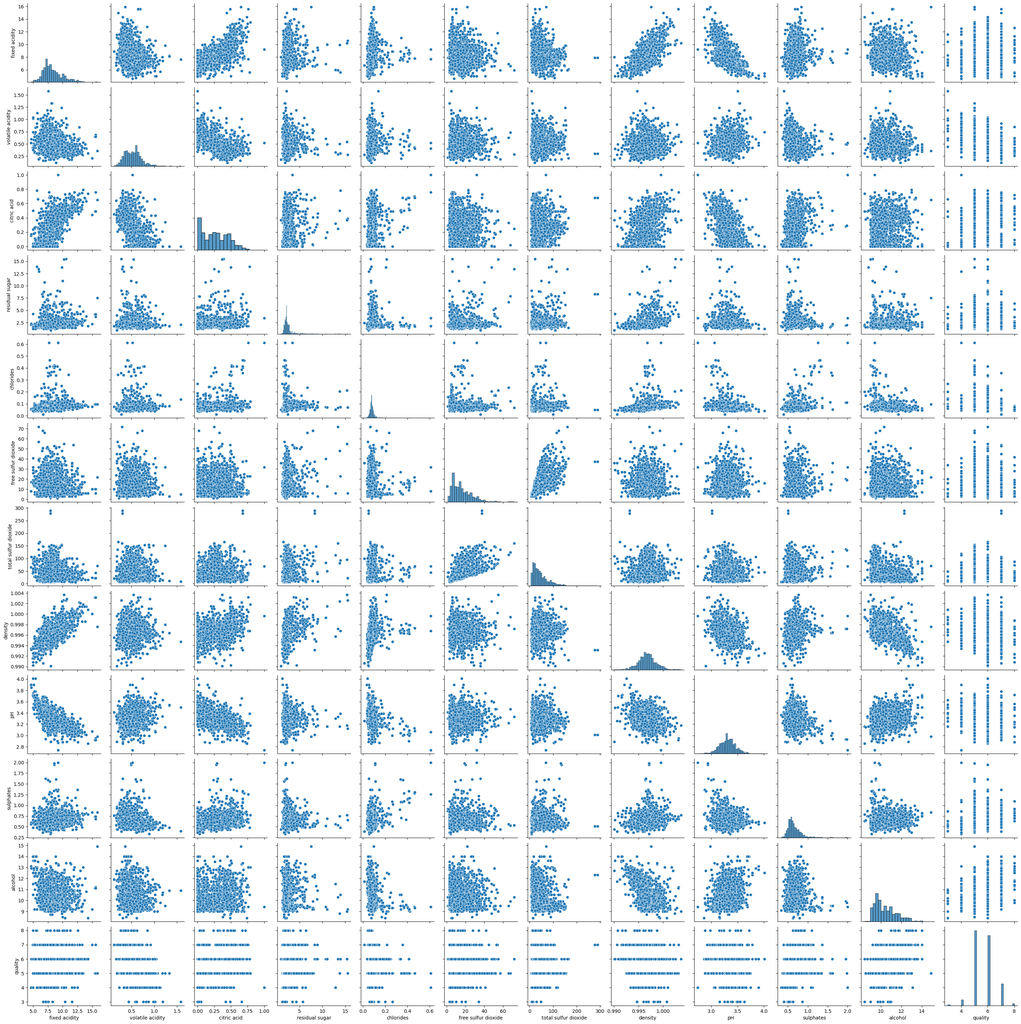

```python
# insert your code here
sns.pairplot(data=wine)
```

```python
wine.sort_values(by='total sulfur dioxide', ascending=False)
```

|  | fixed acidity | volatile acidity | citric acid | residual sugar | chlorides | free sulfur dioxide | total sulfur dioxide | density | pH | sulphates | alcohol | quality |
| --- | --- | --- | --- | --- | --- | --- | --- | --- | --- | --- | --- | --- |
| 1081 | 7.9 | 0.300 | 0.68 | 8.3 | 0.050 | 37.5 | 289.0 | 0.99316 | 3.01 | 0.51 | 12.3 | 7 |
| 1079 | 7.9 | 0.300 | 0.68 | 8.3 | 0.050 | 37.5 | 278.0 | 0.99316 | 3.01 | 0.51 | 12.3 | 7 |
| 354 | 6.1 | 0.210 | 0.40 | 1.4 | 0.066 | 40.5 | 165.0 | 0.99120 | 3.25 | 0.59 | 11.9 | 6 |
| 1244 | 5.9 | 0.290 | 0.25 | 13.4 | 0.067 | 72.0 | 160.0 | 0.99721 | 3.33 | 0.54 | 10.3 | 6 |
| 651 | 9.8 | 0.880 | 0.25 | 2.5 | 0.104 | 35.0 | 155.0 | 1.00100 | 3.41 | 0.67 | 11.2 | 5 |
| ... | ... | ... | ... | ... | ... | ... | ... | ... | ... | ... | ... | ... |
| 986 | 9.8 | 0.340 | 0.39 | 1.4 | 0.066 | 3.0 | 7.0 | 0.99470 | 3.19 | 0.55 | 11.4 | 7 |
| 813 | 6.9 | 0.390 | 0.24 | 2.1 | 0.102 | 4.0 | 7.0 | 0.99462 | 3.44 | 0.58 | 11.4 | 4 |
| 915 | 8.6 | 0.315 | 0.40 | 2.2 | 0.079 | 3.0 | 6.0 | 0.99512 | 3.27 | 0.67 | 11.9 | 6 |
| 984 | 12.2 | 0.450 | 0.49 | 1.4 | 0.075 | 3.0 | 6.0 | 0.99690 | 3.13 | 0.63 | 10.4 | 5 |
| 979 | 12.2 | 0.450 | 0.49 | 1.4 | 0.075 | 3.0 | 6.0 | 0.99690 | 3.13 | 0.63 | 10.4 | 5 |

1599 rows × 12 columns

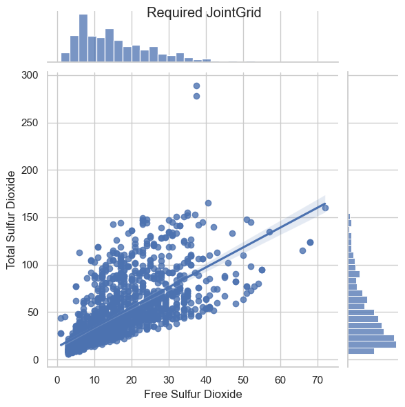

```python
sns.set(style="whitegrid")

g = sns.JointGrid(data=wine, x="free sulfur dioxide", y="total sulfur dioxide")

sns.regplot(data=wine, x="free sulfur dioxide", y="total sulfur dioxide", ax=g.ax_joint)
sns.histplot(data=wine, x="free sulfur dioxide", ax=g.ax_marg_x)
sns.histplot(data=wine, y="total sulfur dioxide", ax=g.ax_marg_y)

g.set_axis_labels("Free Sulfur Dioxide", "Total Sulfur Dioxide")
g.fig.suptitle("Required JointGrid")
```

## Ordinary Least Squares (OLS) Regression

```python
import statsmodels.api as sm
import statsmodels.formula.api as smf
```

Remember that statsmodels uses R-Style formulas: y ~ x1 + x2 + x3 + ...

1. y represents the outcome/dependent variable
2. x1, x2, x3, etc represent explanatory/independent variables

### Q3: Create a regression model with "total sulfur dioxide" as the dependent variable and "free sulfur dioxide" as the predictor variable.

Report the following:

1. Coefficient of determination (i.e. $r^2$)
2. Whether the regression is statistically significant
3. An estimate for the value of "total sulfur dioxide" when the value of "free sulfur dioxide" is 60.

```python
model = smf.ols("Q('total sulfur dioxide') ~ Q('free sulfur dioxide')", data=wine).fit()
model.summary()
```

OLS Regression Results

| Dep. Variable: | Q('total sulfur dioxide') | R-squared: | 0.446 |
| --- | --- | --- | --- |
| Model: | OLS | Adj. R-squared: | 0.445 |
| Method: | Least Squares | F-statistic: | 1285. |
| Date: | Thu, 28 Sep 2023 | Prob (F-statistic): | 6.40e-207 |
| Time: | 14:11:27 | Log-Likelihood: | -7382.4 |
| No. Observations: | 1599 | AIC: | 1.477e+04 |
| Df Residuals: | 1597 | BIC: | 1.478e+04 |
| Df Model: | 1 |  |  |
| Covariance Type: | nonrobust |  |  |

|  | coef | std err | t | P>\|t\| | [0.025 | 0.975] |
| --- | --- | --- | --- | --- | --- | --- |
| Intercept | 13.1354 | 1.114 | 11.795 | 0.000 | 10.951 | 15.320 |
| Q('free sulfur dioxide') | 2.0997 | 0.059 | 35.840 | 0.000 | 1.985 | 2.215 |

| Omnibus: | 621.223 | Durbin-Watson: | 1.553 |
| --- | --- | --- | --- |
| Prob(Omnibus): | 0.000 | Jarque-Bera (JB): | 3163.294 |
| Skew: | 1.767 | Prob(JB): | 0.00 |
| Kurtosis: | 8.915 | Cond. No. | 34.6 |

Notes:  
[1] Standard Errors assume that the covariance matrix of the errors is correctly specified.

```python
model0 = smf.ols(" pH ~ density", data=wine).fit()
model0.summary()
```

OLS Regression Results

| Dep. Variable: | pH | R-squared: | 0.117 |
| --- | --- | --- | --- |
| Model: | OLS | Adj. R-squared: | 0.116 |
| Method: | Least Squares | F-statistic: | 211.1 |
| Date: | Thu, 28 Sep 2023 | Prob (F-statistic): | 5.12e-45 |
| Time: | 14:05:34 | Log-Likelihood: | 818.29 |
| No. Observations: | 1599 | AIC: | -1633. |
| Df Residuals: | 1597 | BIC: | -1622. |
| Df Model: | 1 |  |  |
| Covariance Type: | nonrobust |  |  |

|  | coef | std err | t | P>\|t\| | [0.025 | 0.975] |
| --- | --- | --- | --- | --- | --- | --- |
| Intercept | 31.1716 | 1.917 | 16.256 | 0.000 | 27.411 | 34.933 |
| density | -27.9515 | 1.924 | -14.530 | 0.000 | -31.725 | -24.178 |

| Omnibus: | 25.164 | Durbin-Watson: | 1.613 |
| --- | --- | --- | --- |
| Prob(Omnibus): | 0.000 | Jarque-Bera (JB): | 42.630 |
| Skew: | 0.094 | Prob(JB): | 5.53e-10 |
| Kurtosis: | 3.778 | Cond. No. | 1.06e+03 |

Notes:  
[1] Standard Errors assume that the covariance matrix of the errors is correctly specified.  
[2] The condition number is large, 1.06e+03. This might indicate that there are  
strong multicollinearity or other numerical problems.

Exercise: Putting our ideas together

Download the Szeged weather dataset from https://www.kaggle.com/datasets/budincsevity/szeged-weather

1. Create a regression model with "apparent temperature" as the dependent variable and "temperature" as the predictor variable. Report the following:
   1. Coefficient of determination (i.e. $r^2$)
   2. Whether the regression is statistically significant
   3. An estimate for the value of "apparent temperature" when the value of "temperature" is 10.
2. Create a regression model with "apparent temperature" as the dependent variable and "temperature" and "humidity" as the predictor variables. Report the following:
   1. Coefficient of determination (i.e. $r^2$)
   2. Whether the regression is statistically significant
   3. An estimate for the value of "apparent temperature" when the value of "temperature" is 10 and "humidity" is 0.5.

Use as many code and markdown cells as you need to answer the questions.

```python
weather = pd.read_csv('./weatherHistory.csv')
weather.head()
```

|  | Formatted Date | Summary | Precip Type | Temperature (C) | Apparent Temperature (C) | Humidity | Wind Speed (km/h) | Wind Bearing (degrees) | Visibility (km) | Loud Cover | Pressure (millibars) | Daily Summary |
| --- | --- | --- | --- | --- | --- | --- | --- | --- | --- | --- | --- | --- |
| 0 | 2006-04-01 00:00:00.000 +0200 | Partly Cloudy | rain | 9.472222 | 7.388889 | 0.89 | 14.1197 | 251.0 | 15.8263 | 0.0 | 1015.13 | Partly cloudy throughout the day. |
| 1 | 2006-04-01 01:00:00.000 +0200 | Partly Cloudy | rain | 9.355556 | 7.227778 | 0.86 | 14.2646 | 259.0 | 15.8263 | 0.0 | 1015.63 | Partly cloudy throughout the day. |
| 2 | 2006-04-01 02:00:00.000 +0200 | Mostly Cloudy | rain | 9.377778 | 9.377778 | 0.89 | 3.9284 | 204.0 | 14.9569 | 0.0 | 1015.94 | Partly cloudy throughout the day. |
| 3 | 2006-04-01 03:00:00.000 +0200 | Partly Cloudy | rain | 8.288889 | 5.944444 | 0.83 | 14.1036 | 269.0 | 15.8263 | 0.0 | 1016.41 | Partly cloudy throughout the day. |
| 4 | 2006-04-01 04:00:00.000 +0200 | Mostly Cloudy | rain | 8.755556 | 6.977778 | 0.83 | 11.0446 | 259.0 | 15.8263 | 0.0 | 1016.51 | Partly cloudy throughout the day. |

```python
model0 = smf.ols(" Q('Apparent Temperature (C)') ~ Q('Temperature (C)') ", data=weather).fit()
model0.summary()
```

OLS Regression Results

| Dep. Variable: | Q('Apparent Temperature (C)') | R-squared: | 0.985 |
| --- | --- | --- | --- |
| Model: | OLS | Adj. R-squared: | 0.985 |
| Method: | Least Squares | F-statistic: | 6.470e+06 |
| Date: | Thu, 28 Sep 2023 | Prob (F-statistic): | 0.00 |
| Time: | 14:44:50 | Log-Likelihood: | -1.6190e+05 |
| No. Observations: | 96453 | AIC: | 3.238e+05 |
| Df Residuals: | 96451 | BIC: | 3.238e+05 |
| Df Model: | 1 |  |  |
| Covariance Type: | nonrobust |  |  |

|  | coef | std err | t | P>\|t\| | [0.025 | 0.975] |
| --- | --- | --- | --- | --- | --- | --- |
| Intercept | -2.4100 | 0.007 | -360.775 | 0.000 | -2.423 | -2.397 |
| Q('Temperature (C)') | 1.1117 | 0.000 | 2543.612 | 0.000 | 1.111 | 1.113 |

| Omnibus: | 4226.905 | Durbin-Watson: | 0.384 |
| --- | --- | --- | --- |
| Prob(Omnibus): | 0.000 | Jarque-Bera (JB): | 5588.617 |
| Skew: | -0.449 | Prob(JB): | 0.00 |
| Kurtosis: | 3.763 | Cond. No. | 24.5 |

Notes:  
[1] Standard Errors assume that the covariance matrix of the errors is correctly specified.

significant since the R2 close to 1

```python
model0 = smf.ols(" Q('Apparent Temperature (C)') ~ (Q('Temperature (C)') * Q('Humidity')) ", data=weather).fit()
model0.summary()
```

OLS Regression Results

| Dep. Variable: | Q('Apparent Temperature (C)') | R-squared: | 0.987 |
| --- | --- | --- | --- |
| Model: | OLS | Adj. R-squared: | 0.987 |
| Method: | Least Squares | F-statistic: | 2.386e+06 |
| Date: | Thu, 28 Sep 2023 | Prob (F-statistic): | 0.00 |
| Time: | 14:43:49 | Log-Likelihood: | -1.5709e+05 |
| No. Observations: | 96453 | AIC: | 3.142e+05 |
| Df Residuals: | 96449 | BIC: | 3.142e+05 |
| Df Model: | 3 |  |  |
| Covariance Type: | nonrobust |  |  |

|  | coef | std err | t | P>\|t\| | [0.025 | 0.975] |
| --- | --- | --- | --- | --- | --- | --- |
| Intercept | -3.0285 | 0.037 | -81.935 | 0.000 | -3.101 | -2.956 |
| Q('Temperature (C)') | 1.0628 | 0.002 | 646.540 | 0.000 | 1.060 | 1.066 |
| Q('Humidity') | 0.5083 | 0.044 | 11.588 | 0.000 | 0.422 | 0.594 |
| Q('Temperature (C)'):Q('Humidity') | 0.1091 | 0.002 | 50.429 | 0.000 | 0.105 | 0.113 |

| Omnibus: | 2848.637 | Durbin-Watson: | 0.418 |
| --- | --- | --- | --- |
| Prob(Omnibus): | 0.000 | Jarque-Bera (JB): | 7556.088 |
| Skew: | -0.029 | Prob(JB): | 0.00 |
| Kurtosis: | 4.370 | Cond. No. | 257. |

Notes:  
[1] Standard Errors assume that the covariance matrix of the errors is correctly specified.

significant since the R2 close to 1

## Hypothesis testing (t-test and ANOVA)

```python
import numpy as np
import pandas as pd
import seaborn as sns
import scipy
```

```python
import statsmodels.api as sm
from statsmodels.formula.api import ols
```

For this section, we draw our inspiration from the FiveThirtyEight article "‘Straight Outta Compton’ Is The Rare Biopic Not About White Dudes" (https://fivethirtyeight.com/features/straight-outta-compton-is-the-rare-biopic-not-about-white-dudes/). FiveThiryEight has a great habit of publishing the data that underpin their stories and those data are available via GitHub so it's easy to load them into a DataFrame:

```python
url = "https://raw.githubusercontent.com/fivethirtyeight/data/master/biopics/biopics.csv"
```

```python
biopics = pd.read_csv(url,encoding="latin1")
```

```python
biopics.head()
```

|  | title | site | country | year_release | box_office | director | number_of_subjects | subject | type_of_subject | race_known | subject_race | person_of_color | subject_sex | lead_actor_actress |
| --- | --- | --- | --- | --- | --- | --- | --- | --- | --- | --- | --- | --- | --- | --- |
| 0 | 10 Rillington Place | http://www.imdb.com/title/tt0066730/ | UK | 1971 | - | Richard Fleischer | 1 | John Christie | Criminal | Unknown | NaN | 0 | Male | Richard Attenborough |
| 1 | 12 Years a Slave | http://www.imdb.com/title/tt2024544/ | US/UK | 2013 | $56.7M | Steve McQueen | 1 | Solomon Northup | Other | Known | African American | 1 | Male | Chiwetel Ejiofor |
| 2 | 127 Hours | http://www.imdb.com/title/tt1542344/ | US/UK | 2010 | $18.3M | Danny Boyle | 1 | Aron Ralston | Athlete | Unknown | NaN | 0 | Male | James Franco |
| 3 | 1987 | http://www.imdb.com/title/tt2833074/ | Canada | 2014 | - | Ricardo Trogi | 1 | Ricardo Trogi | Other | Known | White | 0 | Male | Jean-Carl Boucher |
| 4 | 20 Dates | http://www.imdb.com/title/tt0138987/ | US | 1998 | $537K | Myles Berkowitz | 1 | Myles Berkowitz | Other | Unknown | NaN | 0 | Male | Myles Berkowitz |

We're interested in the 'box_office' variable, which is an oddly-formatted representation of the box-office earnings for each movie. We're going to create a function that converts representations like '$56.7M' to '56700000'. How?

Time for some regular expressions (yay!):

## Q6: Fill in the regular expression

```python
import re
import numpy as np

def box_office_dollars(earnings):
    m = re.match(r'\$([0-9.]+)([KM]?)',earnings)
    if not m:
        return np.NaN
    ret = m.group(1)
    if not ret:
        return np.NaN
    try:
        ret = float(ret)
    except:
        return np.NaN
    if m.group(2) == 'M':
        return ret * 1_000_000
    if m.group(2) == 'K':
        return ret * 1_000
    return ret

# Test out our function using assert statements
assert(box_office_dollars("$1") == 1.0)
assert(box_office_dollars("$537K") == 537000.0)
assert(box_office_dollars("$1M") == 1000000.0)
assert(np.isnan(box_office_dollars("-")))
```

And apply it to our DataFrame, creating a new column called 'box_office_dollars'

```python
biopics['box_office_dollars'] = biopics['box_office'].apply(box_office_dollars)
```

```python
biopics.head()
```

|  | title | site | country | year_release | box_office | director | number_of_subjects | subject | type_of_subject | race_known | subject_race | person_of_color | subject_sex | lead_actor_actress | box_office_dollars |
| --- | --- | --- | --- | --- | --- | --- | --- | --- | --- | --- | --- | --- | --- | --- | --- |
| 0 | 10 Rillington Place | http://www.imdb.com/title/tt0066730/ | UK | 1971 | - | Richard Fleischer | 1 | John Christie | Criminal | Unknown | NaN | 0 | Male | Richard Attenborough | NaN |
| 1 | 12 Years a Slave | http://www.imdb.com/title/tt2024544/ | US/UK | 2013 | $56.7M | Steve McQueen | 1 | Solomon Northup | Other | Known | African American | 1 | Male | Chiwetel Ejiofor | 56700000.0 |
| 2 | 127 Hours | http://www.imdb.com/title/tt1542344/ | US/UK | 2010 | $18.3M | Danny Boyle | 1 | Aron Ralston | Athlete | Unknown | NaN | 0 | Male | James Franco | 18300000.0 |
| 3 | 1987 | http://www.imdb.com/title/tt2833074/ | Canada | 2014 | - | Ricardo Trogi | 1 | Ricardo Trogi | Other | Known | White | 0 | Male | Jean-Carl Boucher | NaN |
| 4 | 20 Dates | http://www.imdb.com/title/tt0138987/ | US | 1998 | $537K | Myles Berkowitz | 1 | Myles Berkowitz | Other | Unknown | NaN | 0 | Male | Myles Berkowitz | 537000.0 |

## Q7: What should we do with our missing values:

```python
# insert your code here
biopics.dropna(subset=['box_office_dollars'], inplace=True)
```

As always, let's take a look at the distribution of our variable:

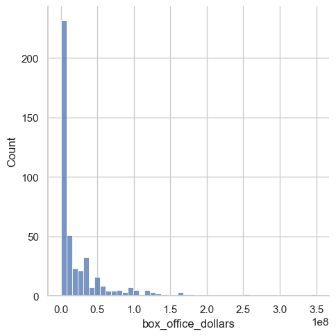

```python
sns.displot(biopics['box_office_dollars'])
```

Hmmmm. That doesn't look good (why?) .

Let's see if we can make that look a bit more like a normal distribution. Let's apply a log transform:

```python
biopics['log_box_office_dollars'] = np.log(biopics['box_office_dollars'])
```

```python
biopics.head()
```

|  | title | site | country | year_release | box_office | director | number_of_subjects | subject | type_of_subject | race_known | subject_race | person_of_color | subject_sex | lead_actor_actress | box_office_dollars | log_box_office_dollars |
| --- | --- | --- | --- | --- | --- | --- | --- | --- | --- | --- | --- | --- | --- | --- | --- | --- |
| 1 | 12 Years a Slave | http://www.imdb.com/title/tt2024544/ | US/UK | 2013 | $56.7M | Steve McQueen | 1 | Solomon Northup | Other | Known | African American | 1 | Male | Chiwetel Ejiofor | 56700000.0 | 17.853285 |
| 2 | 127 Hours | http://www.imdb.com/title/tt1542344/ | US/UK | 2010 | $18.3M | Danny Boyle | 1 | Aron Ralston | Athlete | Unknown | NaN | 0 | Male | James Franco | 18300000.0 | 16.722412 |
| 4 | 20 Dates | http://www.imdb.com/title/tt0138987/ | US | 1998 | $537K | Myles Berkowitz | 1 | Myles Berkowitz | Other | Unknown | NaN | 0 | Male | Myles Berkowitz | 537000.0 | 13.193753 |
| 5 | 21 | http://www.imdb.com/title/tt0478087/ | US | 2008 | $81.2M | Robert Luketic | 1 | Jeff Ma | Other | Known | Asian American | 1 | Male | Jim Sturgess | 81200000.0 | 18.212426 |
| 6 | 24 Hour Party People | http://www.imdb.com/title/tt0274309/ | UK | 2002 | $1.13M | Michael Winterbottom | 1 | Tony Wilson | Musician | Known | White | 0 | Male | Steve Coogan | 1130000.0 | 13.937728 |

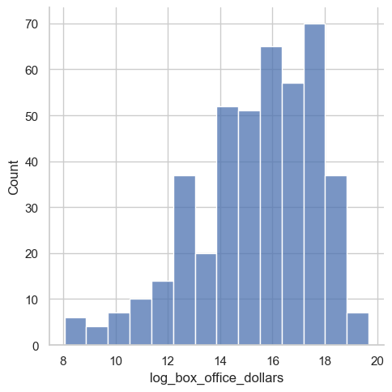

```python
sns.displot(biopics['log_box_office_dollars'])
```

## Q8a: Use a boxplot to look at the relationship of log(box_office_dollars) and whether the subject of the biopic was a person of color or not

```python
# insert your code here
biopics.person_of_color.value_counts()
```

```
person_of_color
0    361
1     76
Name: count, dtype: int64
```

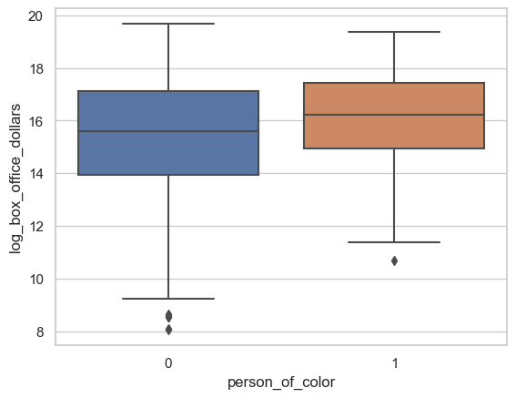

```python
sns.boxplot(data=biopics, x='person_of_color', y = 'log_box_office_dollars')
```

## Q8b: Does it look like there's a difference between the two groups?

Yes, the mean and q1,q3 are different.

## Q9: Conduct an ANOVA to determine if there are statistically significant differences between the two groups.

```python
# insert your code here
model = ols('log_box_office_dollars ~ person_of_color',biopics).fit()
model.summary()
```

OLS Regression Results

| Dep. Variable: | log_box_office_dollars | R-squared: | 0.009 |
| --- | --- | --- | --- |
| Model: | OLS | Adj. R-squared: | 0.007 |
| Method: | Least Squares | F-statistic: | 4.127 |
| Date: | Thu, 28 Sep 2023 | Prob (F-statistic): | 0.0428 |
| Time: | 15:24:34 | Log-Likelihood: | -984.42 |
| No. Observations: | 437 | AIC: | 1973. |
| Df Residuals: | 435 | BIC: | 1981. |
| Df Model: | 1 |  |  |
| Covariance Type: | nonrobust |  |  |

|  | coef | std err | t | P>\|t\| | [0.025 | 0.975] |
| --- | --- | --- | --- | --- | --- | --- |
| Intercept | 15.2572 | 0.121 | 125.644 | 0.000 | 15.018 | 15.496 |
| person_of_color | 0.5915 | 0.291 | 2.031 | 0.043 | 0.019 | 1.164 |

| Omnibus: | 34.714 | Durbin-Watson: | 1.793 |
| --- | --- | --- | --- |
| Prob(Omnibus): | 0.000 | Jarque-Bera (JB): | 41.072 |
| Skew: | -0.745 | Prob(JB): | 1.21e-09 |
| Kurtosis: | 3.182 | Cond. No. | 2.73 |

Notes:  
[1] Standard Errors assume that the covariance matrix of the errors is correctly specified.

## The t-test

To test of there's a statistically significant difference between two means, we can use the independent sample t-test. First, load up the right package:

```python
from scipy.stats import ttest_ind
```

It's more readable if we split the data into two samples:

```python
poc = biopics[biopics["person_of_color"] == 1]
not_poc = biopics[biopics["person_of_color" ] == 0]
```

```python
ttest_ind(poc["log_box_office_dollars"],not_poc["log_box_office_dollars"])
```

```
TtestResult(statistic=2.0314176362558167, pvalue=0.042820052741479, df=435.0)
```

## Q10: What does that mean?

There is significance between mean value and bar

## ANOVA

Ok, that's pretty straight-forward. Let's look at a more complex problem:

```python
biopics.subject_race.value_counts().sort_index()
```

```
subject_race
African                        7
African American              31
Asian                          4
Asian American                 3
Caribbean                      1
Hispanic (Latin American)     10
Hispanic (Latina)              1
Hispanic (Latino)              4
Hispanic (White)               4
Indian                         1
Mediterranean                  1
Middle Eastern                 5
Middle Eastern (White)         8
Multi racial                  17
Native American                2
White                        218
Name: count, dtype: int64
```

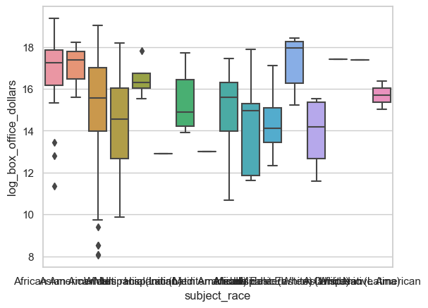

```python
sns.boxplot(x="subject_race",y="log_box_office_dollars",data=biopics)
```

Without getting too worred about the fact that the axes are unreadable, it looks like there are some differences between the different groups. But are they real?

Let's start with an ANOVA:

```python
box_office_dollars_lm = ols('log_box_office_dollars ~ subject_race', data=biopics).fit()
table = sm.stats.anova_lm(box_office_dollars_lm, typ=2) # Type 2 ANOVA DataFrame: no interaction effect
table
```

|  | sum_sq | df | F | PR(>F) |
| --- | --- | --- | --- | --- |
| subject_race | 182.728250 | 15.0 | 2.566995 | 0.001263 |
| Residual | 1428.419809 | 301.0 | NaN | NaN |

```python
res = smf.ols('log_box_office_dollars ~ subject_race',biopics).fit()
print(res.summary())
```

```
                              OLS Regression Results
==================================================================================
Dep. Variable:     log_box_office_dollars   R-squared:                       0.113
Model:                                OLS   Adj. R-squared:                  0.069
Method:                     Least Squares   F-statistic:                     2.567
Date:                    Thu, 28 Sep 2023   Prob (F-statistic):            0.00126
Time:                            15:37:51   Log-Likelihood:                -688.41
No. Observations:                     317   AIC:                             1409.
Df Residuals:                         301   BIC:                             1469.
Df Model:                              15
Covariance Type:                nonrobust
=============================================================================================================
                                                coef    std err          t      P>|t|      [0.025      0.975]
-------------------------------------------------------------------------------------------------------------
Intercept                                    14.9040      0.823     18.101      0.000      13.284      16.524
subject_race[T.African American]              1.9884      0.912      2.181      0.030       0.194       3.782
subject_race[T.Asian]                        -1.0387      1.365     -0.761      0.447      -3.726       1.648
subject_race[T.Asian American]                2.1526      1.503      1.432      0.153      -0.806       5.111
subject_race[T.Caribbean]                     2.5170      2.329      1.081      0.281      -2.066       7.100
subject_race[T.Hispanic (Latin American)]     0.4535      1.074      0.422      0.673      -1.659       2.566
subject_race[T.Hispanic (Latina)]             2.4782      2.329      1.064      0.288      -2.105       7.061
subject_race[T.Hispanic (Latino)]             1.5807      1.365      1.158      0.248      -1.106       4.268
subject_race[T.Hispanic (White)]             -0.4918      1.365     -0.360      0.719      -3.179       2.195
subject_race[T.Indian]                       -2.0048      2.329     -0.861      0.390      -6.588       2.578
subject_race[T.Mediterranean]                -1.8960      2.329     -0.814      0.416      -6.479       2.687
subject_race[T.Middle Eastern]               -0.5770      1.276     -0.452      0.651      -3.087       1.933
subject_race[T.Middle Eastern (White)]        2.4058      1.127      2.134      0.034       0.187       4.624
subject_race[T.Multi racial]                 -0.6743      0.978     -0.689      0.491      -2.600       1.251
subject_race[T.Native American]               0.7853      1.747      0.450      0.653      -2.652       4.222
subject_race[T.White]                         0.3095      0.836      0.370      0.712      -1.337       1.956
==============================================================================
Omnibus:                       34.832   Durbin-Watson:                   1.861
Prob(Omnibus):                  0.000   Jarque-Bera (JB):               43.396
Skew:                          -0.829   Prob(JB):                     3.77e-10
Kurtosis:                       3.734   Cond. No.                         36.7
==============================================================================

Notes:
[1] Standard Errors assume that the covariance matrix of the errors is correctly specified.
```

### Q11: Is there a statistically significant difference?

yes, p-value indicates that can reject the null hypothesis

Let's apply Tukey's HSD using the same model and see what we get.

### Q12: Write code to use Tukey's HSD test on the subject_race variable and interpret the results.

```python
# insert your code here
biopics.dropna(subset=['subject_race'], inplace=True)
```

```python
from statsmodels.stats.multicomp import pairwise_tukeyhsd
res2 = pairwise_tukeyhsd(biopics['log_box_office_dollars'], biopics['subject_race'])
res2.summary()
```

Multiple Comparison of Means - Tukey HSD, FWER=0.05

| group1 | group2 | meandiff | p-adj | lower | upper | reject |
| --- | --- | --- | --- | --- | --- | --- |
| African | African American | 1.9884 | 0.7096 | -1.1616 | 5.1384 | False |
| African | Asian | -1.0387 | 1.0 | -5.7568 | 3.6794 | False |
| African | Asian American | 2.1526 | 0.9884 | -3.0419 | 7.347 | False |
| African | Caribbean | 2.517 | 0.9995 | -5.5302 | 10.5642 | False |
| African | Hispanic (Latin American) | 0.4535 | 1.0 | -3.2561 | 4.1631 | False |
| African | Hispanic (Latina) | 2.4782 | 0.9996 | -5.569 | 10.5254 | False |
| African | Hispanic (Latino) | 1.5807 | 0.9988 | -3.1374 | 6.2988 | False |
| African | Hispanic (White) | -0.4918 | 1.0 | -5.2099 | 4.2263 | False |
| African | Indian | -2.0048 | 1.0 | -10.052 | 6.0424 | False |
| African | Mediterranean | -1.896 | 1.0 | -9.9432 | 6.1512 | False |
| African | Middle Eastern | -0.577 | 1.0 | -4.9847 | 3.8306 | False |
| African | Middle Eastern (White) | 2.4058 | 0.7418 | -1.4901 | 6.3016 | False |
| African | Multi racial | -0.6743 | 1.0 | -4.0548 | 2.7062 | False |
| African | Native American | 0.7853 | 1.0 | -5.2502 | 6.8207 | False |
| African | White | 0.3095 | 1.0 | -2.581 | 3.1999 | False |
| African American | Asian | -3.0271 | 0.3919 | -7.0263 | 0.9721 | False |
| African American | Asian American | 0.1642 | 1.0 | -4.3872 | 4.7156 | False |
| African American | Caribbean | 0.5286 | 1.0 | -7.1193 | 8.1765 | False |
| African American | Hispanic (Latin American) | -1.5349 | 0.8564 | -4.2724 | 1.2027 | False |
| African American | Hispanic (Latina) | 0.4898 | 1.0 | -7.1581 | 8.1377 | False |
| African American | Hispanic (Latino) | -0.4077 | 1.0 | -4.4068 | 3.5915 | False |
| African American | Hispanic (White) | -2.4801 | 0.7357 | -6.4793 | 1.519 | False |
| African American | Indian | -3.9932 | 0.9133 | -11.6411 | 3.6547 | False |
| African American | Mediterranean | -3.8843 | 0.9298 | -11.5323 | 3.7636 | False |
| African American | Middle Eastern | -2.5654 | 0.5164 | -6.1931 | 1.0623 | False |
| African American | Middle Eastern (White) | 0.4174 | 1.0 | -2.5677 | 3.4025 | False |
| African American | Multi racial | -2.6627 | 0.0064 | -4.9344 | -0.3909 | True |
| African American | Native American | -1.2031 | 1.0 | -6.6949 | 4.2886 | False |
| African American | White | -1.6789 | 0.0073 | -3.1238 | -0.234 | True |
| Asian | Asian American | 3.1913 | 0.8657 | -2.558 | 8.9405 | False |

[output cut: 90 more lines]

### Exercise: Putting our ideas together

Download the chocolate bars rating dataset from https://www.kaggle.com/rtatman/chocolate-bar-ratings.

Use the data to answer the following questions:

1. Is there a statistically significant difference in the average rating of chocolate bars from different countries (use the country of manufacture)? If yes, which countries are different from each other?
2. Explore other variables in the dataset. Is there anything else interesting you can find?

Use as many code and markdown cells as you need to answer the questions.

# END OF NOTEBOOK

## Remember to submit HTML and IPYNB files via Canvas.